# 244 HW 2

Molly Williams

2/13/2019

### 0. Load packages and data

```r
library(tidyverse)
library(plotly)
library(boot)
library(naniar)
library(simputation)

cetaceans <- read_csv("captive_cetacean.csv")
fish_catch <- read_csv("fish_catch.csv")
```

### Task 1: Visualizing Cetaceans in Captivity

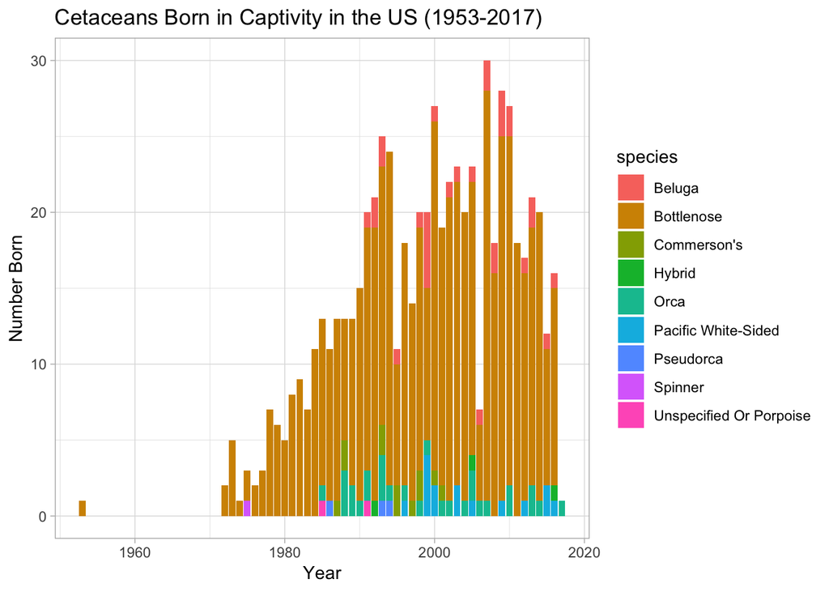

```r
# Filter whale data into new DF that only contains cetaceans born in captivity; retain species and birth year (remove NAs), group by species/birth year
born_in_captivity <- cetaceans %>%
  select(species, acquisition, birthYear) %>%
  filter(acquisition=="Born") %>%
  filter(birthYear !="NA") %>%
  group_by(species, birthYear) %>%
  tally()

# Convert birth year column to numeric, and look at range of years cetaceans were born into captivity
born_in_captivity$birthYear <- as.numeric(born_in_captivity$birthYear)
range(born_in_captivity$birthYear)

# Look at how many unique species were born into captivity
unique(born_in_captivity$species)

# There are several unique names that are the same species (e.g. "white sided, pacific" and "pacific white-sided") that need to be combined:

born_in_captivity$species[born_in_captivity$species=="False Killer Whale"]  <- "Pseudorca"
born_in_captivity$species[born_in_captivity$species=="Beluga Whale"]  <- "Beluga"
born_in_captivity$species[born_in_captivity$species=="Killer Whale; Orca"]  <- "Orca"
born_in_captivity$species[born_in_captivity$species=="White-sided, Pacific"]  <- "Pacific White-Sided"
born_in_captivity$species[born_in_captivity$species=="Backcross"]  <- "Hybrid"

# Check unique names to make sure it worked:
unique(born_in_captivity$species)


# Create a plot to visualize the data!
ggplot(born_in_captivity, aes(x = birthYear,
                 y = n,
                 fill = species)) +
  ggtitle("Cetaceans Born in Captivity in the US (1953-2017)") +
  xlab("Year") +
  ylab("Number Born") +
  geom_bar(stat = "identity", position = "stack") +
  theme_light()
```

### Task 2: Parameter Estimation - Wild Fish Catch

#### 2a-b. Exploratory graph and equation estimation

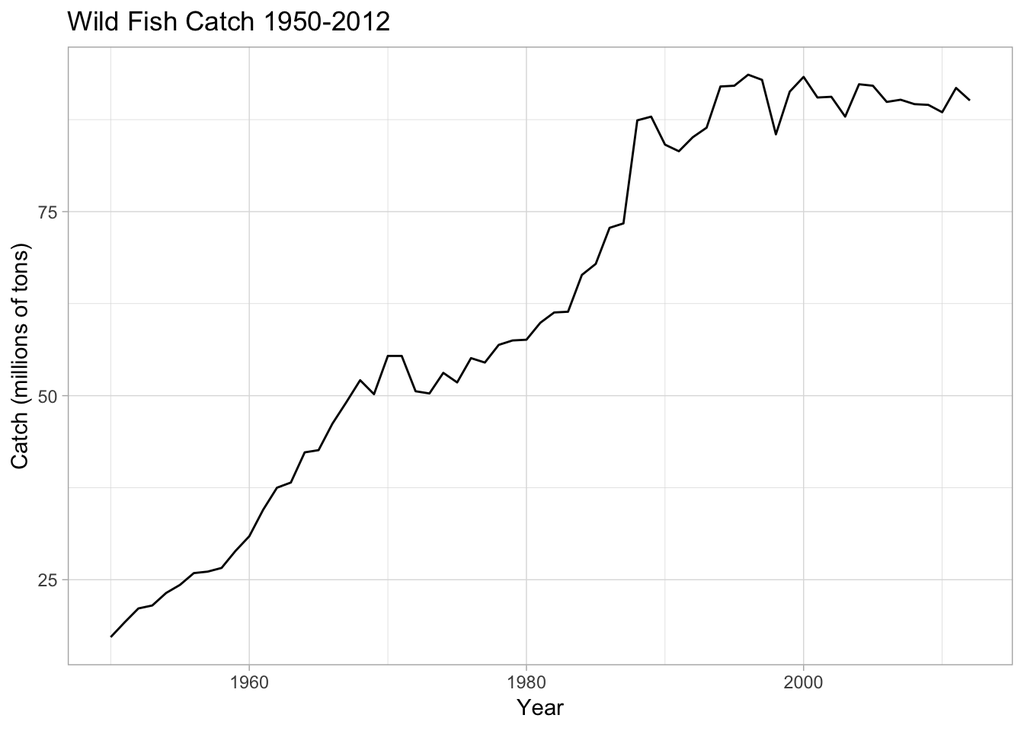

```r
# Exploratory graph:
ggplot(fish_catch, aes(x = year,
                 y = wild_catch)) +
  ggtitle("Wild Fish Catch 1950-2012") +
  xlab("Year") +
  ylab("Catch (millions of tons)") +
  geom_line() +
  theme_light()
```

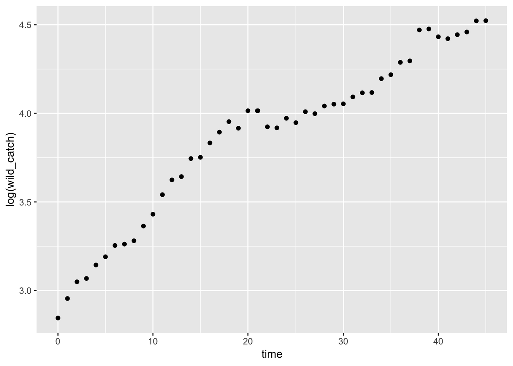

```r
# Add new column to wild_catch to set 1950 to t=0, 1950 to t=1, etc:
fish_catch$time <- fish_catch$year-1950


# Estimate B in logistic growth equation (N = A/(1+Be^(~rt)):
BEstimate <- (93 - 17)/17 # ~4.5

# Estimate r:
exp_phase <- fish_catch %>%
  filter(year<1996)

ggplot(exp_phase, aes(x = time, y = log(wild_catch))) +
  geom_point() # looks linear-ish
```

```r
lm(log(wild_catch) ~ time, data = exp_phase) # r estimate = 0.034
```

```
##
## Call:
## lm(formula = log(wild_catch) ~ time, data = exp_phase)
##
## Coefficients:
## (Intercept)         time
##     3.10561      0.03372
```

*Wild fish catch over time shows logistic growth, according to the equation N = 93/(1+4.5e^(~0.034t)).*

#### 2c-d. Non-linear Least Squares (NLS) model and figure

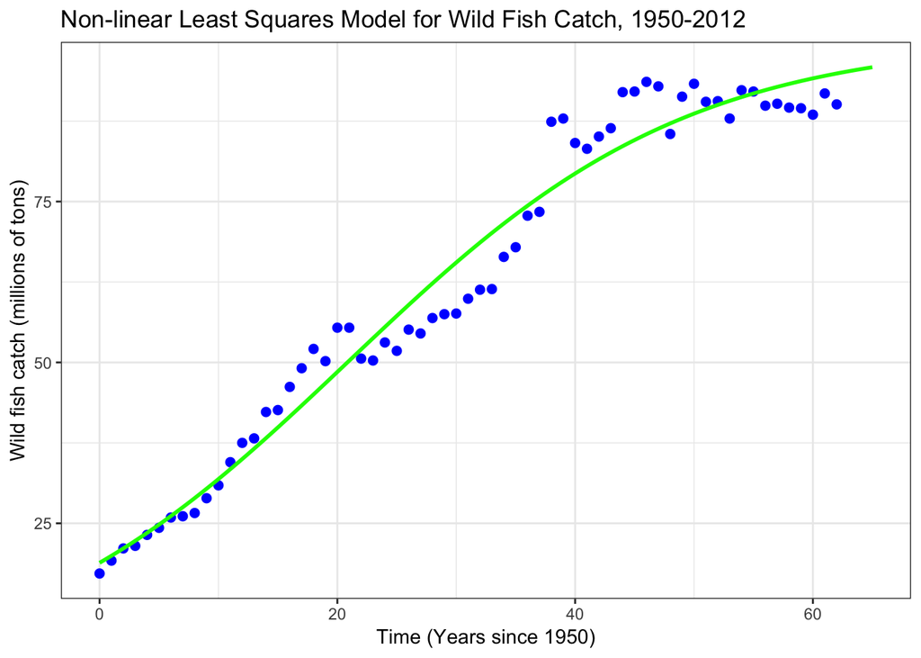

```r
fish_fit <- nls(wild_catch ~ A/(1+B*exp(-r*time)),
                start = list(A = 93, B = 4.5, r = 0.034),
                data = fish_catch,
                trace = TRUE)

A <- coef(fish_fit)[1]
B <- coef(fish_fit)[2]
r <- coef(fish_fit)[3]

# Create a new sequence of time values (time_seq)
time_seq <- seq(0,65, length = 100)

# Plug the new sequence into the model with the parameters A, B and r that we found:

fish_predict <- A/(1+B*exp(-r*time_seq))

predict_df <- data.frame(time_seq, fish_predict)

ggplot(fish_catch, aes(x = time, y = wild_catch)) +
  geom_point(colour = "blue", size = 2) +
  theme_bw() +
  geom_line(data = predict_df, aes(x = time_seq, y = fish_predict), colour = "green", size = 1) +
  xlab("Time (Years since 1950)") +
  ylab("Wild fish catch (millions of tons)") +
  ggtitle("Non-linear Least Squares Model for Wild Fish Catch, 1950-2012")
```

### Task 3: Bootstrapped Confidence Interval for Proportions

```r
nb_queer <- c(1,1,1,1,1,1,1,1,1,1,1,1,1,1,1,1,1,1,1,1,1,1,0,0,0,0,0,0,0,0,0,0,0,0,0,0)

mean_fun <- function(x,i) {mean(x[i])}

set.seed(10)
nb_boot_1000000 <- boot(nb_queer, mean_fun, R = 1000000)

boot.ci(nb_boot_1000000, conf = 0.95)
```

[output not shown]

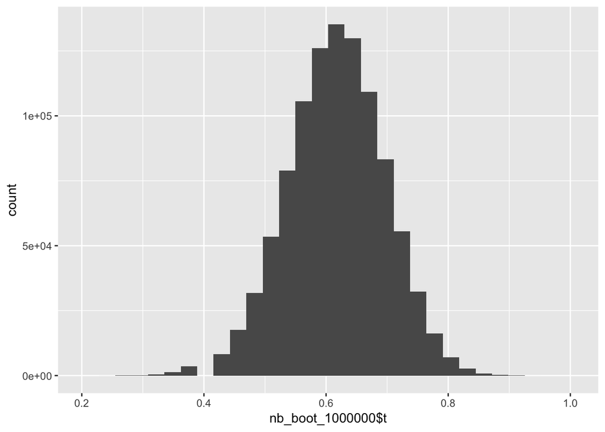

```r
ggplot() +
  aes(nb_boot_1000000$t) +
  geom_histogram()
```

### Task 4: R Studio Conference Talks

#### Teaching data science with puzzles - Irene Steves

- Tidies of March: puzzles that highlight what R/tidyverse are good at; turning messy data into tidy data! Bite size puzzles that focus on core data science skills
- Lots more to wrangling data than just what’s in the tidyverse! :)
- *Question*: How are you promoting these puzzles? How will people know they’re there? Is there a way to share submitted solutions etc?

#### Teaching R using inclusive pedagogy: Practices and lessons learned from over 700 Carpentries workshops - Tracy Teal

- Data is power; data science tools need to be democratized to empower people to answer questions that are important to them
- Important to establish a growth mindset, and for folks to feel like coding is for them (focus on effort, not outcomes); safe space to continue learning (accessible, welcoming)!
- *Question*: What would be the best way to standardize these best practices across R communities?

#### R at the ACLU: Joining tables to to reunite families - Brooke Watson

- No data system in place to organize all the incoming data after the imposition of the family separation policy
- Assertions and filters were used to un-nest data; used leaflet to visualize where the children are
- “the cases we’re fighting are about who gets counted”
- *Question*: What are the future applications of data science to social justice movements? How can it be more quantitative than qualitative?